# 578hw3

#### CSC 578/Section 901

#### Homework 3 (578hw3.ipynb)

```python
import NN578_networkI as network
import numpy as np
import random
import matplotlib.pyplot as plt
```

```python
# Load the dataset (already in the 'one-hot-vector' format for the target)
# Call the function to load the data.
iris_data = network.my_load_csv('iris.csv', 4, 3)
```

[output not shown]

### A) Check network definition code which includes the Modifications described in Part 2 of HW3:

**Train the net1 network (created from iris-423.dat) on the iris data for a maximum of 100 epochs, minibatch_size=5, eta=0.5:**

```python
# Create a network from the saved network
net1 = network.load_network("iris-423.dat")

# Train the network for 100 epochs, with minibatch size 5, eta=0.5 and no testset.
results1 = net1.SGD(iris_data, 100, 5, 0.5)
```

```
[Epoch 0] Training: MSE=0.33989623, CE=1.93947802, LL=1.07270335, Correct: 50/150, Acc: 0.33333333
[Epoch 1] Training: MSE=0.35054136, CE=1.98910892, LL=1.13654524, Correct: 50/150, Acc: 0.33333333
[Epoch 2] Training: MSE=0.33898723, CE=1.93723493, LL=1.12030613, Correct: 50/150, Acc: 0.33333333
[Epoch 3] Training: MSE=0.30402667, CE=1.76598458, LL=0.98309968, Correct: 51/150, Acc: 0.34000000
[Epoch 4] Training: MSE=0.27946742, CE=1.65306466, LL=0.88038172, Correct: 100/150, Acc: 0.66666667
[Epoch 5] Training: MSE=0.25916154, CE=1.56196374, LL=0.80792403, Correct: 100/150, Acc: 0.66666667
[Epoch 6] Training: MSE=0.24333059, CE=1.48939578, LL=0.75466382, Correct: 100/150, Acc: 0.66666667
[Epoch 7] Training: MSE=0.23153034, CE=1.43260666, LL=0.71520737, Correct: 100/150, Acc: 0.66666667
[Epoch 8] Training: MSE=0.22283392, CE=1.38810432, LL=0.68570972, Correct: 100/150, Acc: 0.66666667
[Epoch 9] Training: MSE=0.21638630, CE=1.35286947, LL=0.66332470, Correct: 100/150, Acc: 0.66666667
[Epoch 10] Training: MSE=0.21155054, CE=1.32462457, LL=0.64601912, Correct: 100/150, Acc: 0.66666667
[Epoch 11] Training: MSE=0.20789080, CE=1.30174644, LL=0.63237556, Correct: 100/150, Acc: 0.66666667
[Epoch 12] Training: MSE=0.20511694, CE=1.28309614, LL=0.62141506, Correct: 100/150, Acc: 0.66666667
[Epoch 13] Training: MSE=0.20302930, CE=1.26784584, LL=0.61246681, Correct: 100/150, Acc: 0.66666667
[Epoch 14] Training: MSE=0.20147235, CE=1.25532061, LL=0.60507322, Correct: 100/150, Acc: 0.66666667
[Epoch 15] Training: MSE=0.20030105, CE=1.24486556, LL=0.59890049, Correct: 100/150, Acc: 0.66666667
[Epoch 16] Training: MSE=0.19936157, CE=1.23573475, LL=0.59362044, Correct: 100/150, Acc: 0.66666667
[Epoch 17] Training: MSE=0.19846286, CE=1.22686360, LL=0.58868507, Correct: 100/150, Acc: 0.66666667
[Epoch 18] Training: MSE=0.19720532, CE=1.21573647, LL=0.58262039, Correct: 100/150, Acc: 0.66666667
[Epoch 19] Training: MSE=0.19438939, CE=1.19440802, LL=0.57068463, Correct: 100/150, Acc: 0.66666667
[Epoch 20] Training: MSE=0.19092608, CE=1.16732717, LL=0.55286608, Correct: 100/150, Acc: 0.66666667
[Epoch 21] Training: MSE=0.19096008, CE=1.16133018, LL=0.54312471, Correct: 100/150, Acc: 0.66666667
[Epoch 22] Training: MSE=0.19353066, CE=1.16929236, LL=0.53927297, Correct: 100/150, Acc: 0.66666667
[Epoch 23] Training: MSE=0.19776431, CE=1.18560542, LL=0.54036904, Correct: 100/150, Acc: 0.66666667
[Epoch 24] Training: MSE=0.20178627, CE=1.20164379, LL=0.54486505, Correct: 100/150, Acc: 0.66666667
[Epoch 25] Training: MSE=0.20662471, CE=1.22178025, LL=0.54960066, Correct: 100/150, Acc: 0.66666667
[Epoch 26] Training: MSE=0.21241592, CE=1.24698192, LL=0.55558579, Correct: 100/150, Acc: 0.66666667
[Epoch 27] Training: MSE=0.22371923, CE=1.30062268, LL=0.56667376, Correct: 100/150, Acc: 0.66666667
[Epoch 28] Training: MSE=0.24331341, CE=1.40561068, LL=0.59374334, Correct: 100/150, Acc: 0.66666667
[Epoch 29] Training: MSE=0.24199777, CE=1.39912289, LL=0.59138124, Correct: 100/150, Acc: 0.66666667
[Epoch 30] Training: MSE=0.23946870, CE=1.38389155, LL=0.59045876, Correct: 100/150, Acc: 0.66666667
[Epoch 31] Training: MSE=0.23599222, CE=1.36317079, LL=0.58667198, Correct: 100/150, Acc: 0.66666667
[Epoch 32] Training: MSE=0.23289589, CE=1.34470190, LL=0.58358964, Correct: 100/150, Acc: 0.66666667
[Epoch 33] Training: MSE=0.23009235, CE=1.32814460, LL=0.58092824, Correct: 100/150, Acc: 0.66666667
[Epoch 34] Training: MSE=0.22722565, CE=1.31165773, LL=0.57818266, Correct: 100/150, Acc: 0.66666667
[Epoch 35] Training: MSE=0.22334286, CE=1.29038726, LL=0.57330663, Correct: 100/150, Acc: 0.66666667
[Epoch 36] Training: MSE=0.22467301, CE=1.29779632, LL=0.57115706, Correct: 100/150, Acc: 0.66666667
[Epoch 37] Training: MSE=0.22330533, CE=1.29038782, LL=0.56749807, Correct: 100/150, Acc: 0.66666667
[Epoch 38] Training: MSE=0.22251684, CE=1.28617554, LL=0.56502888, Correct: 100/150, Acc: 0.66666667
[Epoch 39] Training: MSE=0.22101269, CE=1.27807819, LL=0.56246911, Correct: 100/150, Acc: 0.66666667
```

[output cut: 45 more lines]

```
[Epoch 85] Training: MSE=0.09664843, CE=0.66447854, LL=0.30887734, Correct: 131/150, Acc: 0.87333333
[Epoch 86] Training: MSE=0.09450248, CE=0.65351008, LL=0.30381584, Correct: 131/150, Acc: 0.87333333
[Epoch 87] Training: MSE=0.09252367, CE=0.64333064, LL=0.29912918, Correct: 131/150, Acc: 0.87333333
[Epoch 88] Training: MSE=0.09065901, CE=0.63368593, LL=0.29469877, Correct: 131/150, Acc: 0.87333333
[Epoch 89] Training: MSE=0.08882565, CE=0.62417564, LL=0.29033170, Correct: 131/150, Acc: 0.87333333
[Epoch 90] Training: MSE=0.08696792, CE=0.61453152, LL=0.28589242, Correct: 131/150, Acc: 0.87333333
[Epoch 91] Training: MSE=0.08507876, CE=0.60472286, LL=0.28135439, Correct: 131/150, Acc: 0.87333333
[Epoch 92] Training: MSE=0.08320521, CE=0.59498389, LL=0.27681506, Correct: 133/150, Acc: 0.88666667
[Epoch 93] Training: MSE=0.08142377, CE=0.58569286, LL=0.27244386, Correct: 133/150, Acc: 0.88666667
[Epoch 94] Training: MSE=0.07979103, CE=0.57712893, LL=0.26837303, Correct: 133/150, Acc: 0.88666667
[Epoch 95] Training: MSE=0.07831577, CE=0.56933537, LL=0.26463285, Correct: 133/150, Acc: 0.88666667
[Epoch 96] Training: MSE=0.07697374, CE=0.56219254, LL=0.26118019, Correct: 134/150, Acc: 0.89333333
[Epoch 97] Training: MSE=0.07573288, CE=0.55554221, LL=0.25795193, Correct: 135/150, Acc: 0.90000000
[Epoch 98] Training: MSE=0.07456498, CE=0.54924517, LL=0.25489053, Correct: 136/150, Acc: 0.90666667
[Epoch 99] Training: MSE=0.07344778, CE=0.54319159, LL=0.25194933, Correct: 136/150, Acc: 0.90666667
```

**Create another network by reloading the same saved network and train the network with the same three hyperparameter values, and stopaccuracy=0.75:**

```python
# Create a network from the saved network
net2 = network.load_network("iris-423.dat")

# Train the net2 network for 100 epochs, minibatch size 5, eta=0.5, stopaccuracy=0.75, and no testset
results2 = net2.SGD(iris_data, 100, 5, 0.5, stopaccuracy=0.75)
```

```
[Epoch 0] Training: MSE=0.33989623, CE=1.93947802, LL=1.07270335, Correct: 50/150, Acc: 0.33333333
[Epoch 1] Training: MSE=0.35054136, CE=1.98910892, LL=1.13654524, Correct: 50/150, Acc: 0.33333333
[Epoch 2] Training: MSE=0.33898723, CE=1.93723493, LL=1.12030613, Correct: 50/150, Acc: 0.33333333
[Epoch 3] Training: MSE=0.30402667, CE=1.76598458, LL=0.98309968, Correct: 51/150, Acc: 0.34000000
[Epoch 4] Training: MSE=0.27946742, CE=1.65306466, LL=0.88038172, Correct: 100/150, Acc: 0.66666667
[Epoch 5] Training: MSE=0.25916154, CE=1.56196374, LL=0.80792403, Correct: 100/150, Acc: 0.66666667
[Epoch 6] Training: MSE=0.24333059, CE=1.48939578, LL=0.75466382, Correct: 100/150, Acc: 0.66666667
[Epoch 7] Training: MSE=0.23153034, CE=1.43260666, LL=0.71520737, Correct: 100/150, Acc: 0.66666667
[Epoch 8] Training: MSE=0.22283392, CE=1.38810432, LL=0.68570972, Correct: 100/150, Acc: 0.66666667
[Epoch 9] Training: MSE=0.21638630, CE=1.35286947, LL=0.66332470, Correct: 100/150, Acc: 0.66666667
[Epoch 10] Training: MSE=0.21155054, CE=1.32462457, LL=0.64601912, Correct: 100/150, Acc: 0.66666667
[Epoch 11] Training: MSE=0.20789080, CE=1.30174644, LL=0.63237556, Correct: 100/150, Acc: 0.66666667
[Epoch 12] Training: MSE=0.20511694, CE=1.28309614, LL=0.62141506, Correct: 100/150, Acc: 0.66666667
[Epoch 13] Training: MSE=0.20302930, CE=1.26784584, LL=0.61246681, Correct: 100/150, Acc: 0.66666667
[Epoch 14] Training: MSE=0.20147235, CE=1.25532061, LL=0.60507322, Correct: 100/150, Acc: 0.66666667
[Epoch 15] Training: MSE=0.20030105, CE=1.24486556, LL=0.59890049, Correct: 100/150, Acc: 0.66666667
[Epoch 16] Training: MSE=0.19936157, CE=1.23573475, LL=0.59362044, Correct: 100/150, Acc: 0.66666667
[Epoch 17] Training: MSE=0.19846286, CE=1.22686360, LL=0.58868507, Correct: 100/150, Acc: 0.66666667
[Epoch 18] Training: MSE=0.19720532, CE=1.21573647, LL=0.58262039, Correct: 100/150, Acc: 0.66666667
[Epoch 19] Training: MSE=0.19438939, CE=1.19440802, LL=0.57068463, Correct: 100/150, Acc: 0.66666667
[Epoch 20] Training: MSE=0.19092608, CE=1.16732717, LL=0.55286608, Correct: 100/150, Acc: 0.66666667
[Epoch 21] Training: MSE=0.19096008, CE=1.16133018, LL=0.54312471, Correct: 100/150, Acc: 0.66666667
[Epoch 22] Training: MSE=0.19353066, CE=1.16929236, LL=0.53927297, Correct: 100/150, Acc: 0.66666667
[Epoch 23] Training: MSE=0.19776431, CE=1.18560542, LL=0.54036904, Correct: 100/150, Acc: 0.66666667
[Epoch 24] Training: MSE=0.20178627, CE=1.20164379, LL=0.54486505, Correct: 100/150, Acc: 0.66666667
[Epoch 25] Training: MSE=0.20662471, CE=1.22178025, LL=0.54960066, Correct: 100/150, Acc: 0.66666667
[Epoch 26] Training: MSE=0.21241592, CE=1.24698192, LL=0.55558579, Correct: 100/150, Acc: 0.66666667
[Epoch 27] Training: MSE=0.22371923, CE=1.30062268, LL=0.56667376, Correct: 100/150, Acc: 0.66666667
[Epoch 28] Training: MSE=0.24331341, CE=1.40561068, LL=0.59374334, Correct: 100/150, Acc: 0.66666667
[Epoch 29] Training: MSE=0.24199777, CE=1.39912289, LL=0.59138124, Correct: 100/150, Acc: 0.66666667
[Epoch 30] Training: MSE=0.23946870, CE=1.38389155, LL=0.59045876, Correct: 100/150, Acc: 0.66666667
[Epoch 31] Training: MSE=0.23599222, CE=1.36317079, LL=0.58667198, Correct: 100/150, Acc: 0.66666667
[Epoch 32] Training: MSE=0.23289589, CE=1.34470190, LL=0.58358964, Correct: 100/150, Acc: 0.66666667
[Epoch 33] Training: MSE=0.23009235, CE=1.32814460, LL=0.58092824, Correct: 100/150, Acc: 0.66666667
[Epoch 34] Training: MSE=0.22722565, CE=1.31165773, LL=0.57818266, Correct: 100/150, Acc: 0.66666667
[Epoch 35] Training: MSE=0.22334286, CE=1.29038726, LL=0.57330663, Correct: 100/150, Acc: 0.66666667
[Epoch 36] Training: MSE=0.22467301, CE=1.29779632, LL=0.57115706, Correct: 100/150, Acc: 0.66666667
[Epoch 37] Training: MSE=0.22330533, CE=1.29038782, LL=0.56749807, Correct: 100/150, Acc: 0.66666667
[Epoch 38] Training: MSE=0.22251684, CE=1.28617554, LL=0.56502888, Correct: 100/150, Acc: 0.66666667
[Epoch 39] Training: MSE=0.22101269, CE=1.27807819, LL=0.56246911, Correct: 100/150, Acc: 0.66666667
```

[output cut: 10 more lines]

```
[Epoch 50] Training: MSE=0.20664139, CE=1.20742322, LL=0.53013769, Correct: 102/150, Acc: 0.68000000
[Epoch 51] Training: MSE=0.20585190, CE=1.20331541, LL=0.52882492, Correct: 102/150, Acc: 0.68000000
[Epoch 52] Training: MSE=0.20493768, CE=1.19855574, LL=0.52753879, Correct: 102/150, Acc: 0.68000000
[Epoch 53] Training: MSE=0.20367382, CE=1.19199722, LL=0.52569989, Correct: 102/150, Acc: 0.68000000
[Epoch 54] Training: MSE=0.20210133, CE=1.18388439, LL=0.52332046, Correct: 102/150, Acc: 0.68000000
[Epoch 55] Training: MSE=0.20017765, CE=1.17402428, LL=0.52031668, Correct: 103/150, Acc: 0.68666667
[Epoch 56] Training: MSE=0.19791986, CE=1.16253436, LL=0.51673089, Correct: 103/150, Acc: 0.68666667
[Epoch 57] Training: MSE=0.19535639, CE=1.14958619, LL=0.51262232, Correct: 103/150, Acc: 0.68666667
[Epoch 58] Training: MSE=0.19251818, CE=1.13535662, LL=0.50803700, Correct: 104/150, Acc: 0.69333333
[Epoch 59] Training: MSE=0.18943311, CE=1.11999754, LL=0.50299692, Correct: 105/150, Acc: 0.70000000
[Epoch 60] Training: MSE=0.18612719, CE=1.10364146, LL=0.49751024, Correct: 107/150, Acc: 0.71333333
[Epoch 61] Training: MSE=0.18262490, CE=1.08640345, LL=0.49158036, Correct: 108/150, Acc: 0.72000000
[Epoch 62] Training: MSE=0.17894371, CE=1.06835637, LL=0.48520180, Correct: 109/150, Acc: 0.72666667
[Epoch 63] Training: MSE=0.17508312, CE=1.04947938, LL=0.47834243, Correct: 111/150, Acc: 0.74000000
[Epoch 64] Training: MSE=0.17101285, CE=1.02960346, LL=0.47092162, Correct: 114/150, Acc: 0.76000000
```

### B) Check code with a different, deeper network, in particular the 4-20-7-3 network:

**Create a new network by loading the saved 4-20-7-3 network, then train the network using the same hyperparameters (epochs=100, minibatch_size=5, eta=0.5, stopaccuracy=0.75):**

```python
# Create a network from the saved network 4-20-7-3:
net3 = network.load_network("iris4-20-7-3.dat")

# Train the net3 network for 100 epochs, minibatch size 5, eta=0.5, stopaccuracy=0.75, and no testset
results3 = net3.SGD(iris_data, 100, 5, 0.5, stopaccuracy=0.75)
```

```
[Epoch 0] Training: MSE=0.35101648, CE=1.98991328, LL=1.13575832, Correct: 50/150, Acc: 0.33333333
[Epoch 1] Training: MSE=0.35685102, CE=2.01618235, LL=1.14912048, Correct: 50/150, Acc: 0.33333333
[Epoch 2] Training: MSE=0.35639476, CE=2.01398864, LL=1.14813574, Correct: 50/150, Acc: 0.33333333
[Epoch 3] Training: MSE=0.35437837, CE=2.00490209, LL=1.14575037, Correct: 50/150, Acc: 0.33333333
[Epoch 4] Training: MSE=0.35223003, CE=1.99520139, LL=1.14349029, Correct: 50/150, Acc: 0.33333333
[Epoch 5] Training: MSE=0.35031508, CE=1.98646512, LL=1.14156680, Correct: 50/150, Acc: 0.33333333
[Epoch 6] Training: MSE=0.34871835, CE=1.97904087, LL=1.13981143, Correct: 50/150, Acc: 0.33333333
[Epoch 7] Training: MSE=0.34745549, CE=1.97297198, LL=1.13794379, Correct: 50/150, Acc: 0.33333333
[Epoch 8] Training: MSE=0.34653515, CE=1.96827108, LL=1.13577658, Correct: 50/150, Acc: 0.33333333
[Epoch 9] Training: MSE=0.34597833, CE=1.96497833, LL=1.13322576, Correct: 50/150, Acc: 0.33333333
[Epoch 10] Training: MSE=0.34585849, CE=1.96327553, LL=1.13018086, Correct: 50/150, Acc: 0.33333333
[Epoch 11] Training: MSE=0.34641558, CE=1.96388695, LL=1.12647757, Correct: 50/150, Acc: 0.33333333
[Epoch 12] Training: MSE=0.34829485, CE=1.96910258, LL=1.12193156, Correct: 50/150, Acc: 0.33333333
[Epoch 13] Training: MSE=0.35188427, CE=1.98043795, LL=1.11552936, Correct: 50/150, Acc: 0.33333333
[Epoch 14] Training: MSE=0.35544780, CE=1.99062312, LL=1.10560605, Correct: 50/150, Acc: 0.33333333
[Epoch 15] Training: MSE=0.35629434, CE=1.98841680, LL=1.08903285, Correct: 50/150, Acc: 0.33333333
[Epoch 16] Training: MSE=0.35167728, CE=1.96236428, LL=1.06011415, Correct: 50/150, Acc: 0.33333333
[Epoch 17] Training: MSE=0.34189652, CE=1.91298012, LL=1.01785387, Correct: 50/150, Acc: 0.33333333
[Epoch 18] Training: MSE=0.33022385, CE=1.85315834, LL=0.96803742, Correct: 50/150, Acc: 0.33333333
[Epoch 19] Training: MSE=0.31898719, CE=1.79373434, LL=0.91815137, Correct: 50/150, Acc: 0.33333333
[Epoch 20] Training: MSE=0.30857369, CE=1.73803009, LL=0.87253846, Correct: 73/150, Acc: 0.48666667
[Epoch 21] Training: MSE=0.29883166, CE=1.68617920, LL=0.83259669, Correct: 99/150, Acc: 0.66000000
[Epoch 22] Training: MSE=0.28983778, CE=1.63877994, LL=0.79847476, Correct: 100/150, Acc: 0.66666667
[Epoch 23] Training: MSE=0.28179228, CE=1.59680510, LL=0.76970619, Correct: 100/150, Acc: 0.66666667
[Epoch 24] Training: MSE=0.27482641, CE=1.56076812, LL=0.74550589, Correct: 100/150, Acc: 0.66666667
[Epoch 25] Training: MSE=0.26892582, CE=1.53040590, LL=0.72496739, Correct: 100/150, Acc: 0.66666667
[Epoch 26] Training: MSE=0.26394061, CE=1.50480218, LL=0.70719973, Correct: 100/150, Acc: 0.66666667
[Epoch 27] Training: MSE=0.25964608, CE=1.48273203, LL=0.69144995, Correct: 100/150, Acc: 0.66666667
[Epoch 28] Training: MSE=0.25579916, CE=1.46293691, LL=0.67714808, Correct: 100/150, Acc: 0.66666667
[Epoch 29] Training: MSE=0.25217186, CE=1.44425716, LL=0.66388854, Correct: 100/150, Acc: 0.66666667
[Epoch 30] Training: MSE=0.24857692, CE=1.42572868, LL=0.65141314, Correct: 100/150, Acc: 0.66666667
[Epoch 31] Training: MSE=0.24488810, CE=1.40667087, LL=0.63959586, Correct: 100/150, Acc: 0.66666667
[Epoch 32] Training: MSE=0.24104792, CE=1.38672969, LL=0.62841090, Correct: 100/150, Acc: 0.66666667
[Epoch 33] Training: MSE=0.23706064, CE=1.36585762, LL=0.61788777, Correct: 100/150, Acc: 0.66666667
[Epoch 34] Training: MSE=0.23297404, CE=1.34424136, LL=0.60806825, Correct: 100/150, Acc: 0.66666667
[Epoch 35] Training: MSE=0.22885750, CE=1.32220711, LL=0.59897770, Correct: 101/150, Acc: 0.67333333
[Epoch 36] Training: MSE=0.22478406, CE=1.30013746, LL=0.59061590, Correct: 101/150, Acc: 0.67333333
[Epoch 37] Training: MSE=0.22082080, CE=1.27842027, LL=0.58296494, Correct: 101/150, Acc: 0.67333333
[Epoch 38] Training: MSE=0.21702701, CE=1.25742812, LL=0.57600583, Correct: 102/150, Acc: 0.68000000
[Epoch 39] Training: MSE=0.21345644, CE=1.23751400, LL=0.56973421, Correct: 102/150, Acc: 0.68000000
```

[output cut: 8 more lines]

```
[Epoch 48] Training: MSE=0.19756796, CE=1.14562935, LL=0.54905475, Correct: 103/150, Acc: 0.68666667
[Epoch 49] Training: MSE=0.19416471, CE=1.12731628, LL=0.54201036, Correct: 104/150, Acc: 0.69333333
[Epoch 50] Training: MSE=0.19185666, CE=1.11478337, LL=0.53790347, Correct: 105/150, Acc: 0.70000000
[Epoch 51] Training: MSE=0.18914521, CE=1.10022460, LL=0.53245927, Correct: 105/150, Acc: 0.70000000
[Epoch 52] Training: MSE=0.18658357, CE=1.08644444, LL=0.52728757, Correct: 105/150, Acc: 0.70000000
[Epoch 53] Training: MSE=0.18371481, CE=1.07113656, LL=0.52112249, Correct: 105/150, Acc: 0.70000000
[Epoch 54] Training: MSE=0.18083449, CE=1.05581230, LL=0.51476979, Correct: 105/150, Acc: 0.70000000
[Epoch 55] Training: MSE=0.17780124, CE=1.03978392, LL=0.50782425, Correct: 105/150, Acc: 0.70000000
[Epoch 56] Training: MSE=0.17487039, CE=1.02434706, LL=0.50099791, Correct: 107/150, Acc: 0.71333333
[Epoch 57] Training: MSE=0.17197155, CE=1.00920274, LL=0.49413599, Correct: 108/150, Acc: 0.72000000
[Epoch 58] Training: MSE=0.16919844, CE=0.99485113, LL=0.48755799, Correct: 109/150, Acc: 0.72666667
[Epoch 59] Training: MSE=0.16638703, CE=0.98050039, LL=0.48086780, Correct: 109/150, Acc: 0.72666667
[Epoch 60] Training: MSE=0.16355655, CE=0.96620930, LL=0.47414144, Correct: 109/150, Acc: 0.72666667
[Epoch 61] Training: MSE=0.16060140, CE=0.95142646, LL=0.46709139, Correct: 112/150, Acc: 0.74666667
[Epoch 62] Training: MSE=0.15757755, CE=0.93638462, LL=0.45986411, Correct: 113/150, Acc: 0.75333333
```

### C) Visualize the network learning by creating plots:

**A. First split the dataset randomly into 70% training and 30% test:**

```python
iris_data
random.shuffle(iris_data)
training = iris_data[0:105] # first 70% of the iris_data
test = iris_data[-45:]      # last 30% of the iris_data
```

**B. Create a new network (which has randomly initialized weights) of the size [4,20,3]:**

```python
# Create a new network net4
net4 = network.Network([4,20,3])
```

**C. Train the network for 50 epochs with eta = 0.1 and the minibatch size = 5 (default for stopaccuracy), and save results:**

```python
results4 = net4.SGD(training, 50, 5, 0.1, test)
```

```
[Epoch 0] Training: MSE=0.28661700, CE=2.21861280, LL=1.84252464, Correct: 73/105, Acc: 0.69523810
              Test: MSE=0.33299420, CE=2.62960638, LL=2.22520065, Correct: 27/45, Acc: 0.60000000
[Epoch 1] Training: MSE=0.25439416, CE=2.07224622, LL=1.68279905, Correct: 73/105, Acc: 0.69523810
              Test: MSE=0.30674147, CE=2.51299807, LL=2.07813227, Correct: 27/45, Acc: 0.60000000
[Epoch 2] Training: MSE=0.23515737, CE=1.94759152, LL=1.58169331, Correct: 73/105, Acc: 0.69523810
              Test: MSE=0.29149223, CE=2.40110259, LL=1.97598934, Correct: 27/45, Acc: 0.60000000
[Epoch 3] Training: MSE=0.22512173, CE=1.84381200, LL=1.50088199, Correct: 73/105, Acc: 0.69523810
              Test: MSE=0.28245423, CE=2.28945499, LL=1.88236040, Correct: 27/45, Acc: 0.60000000
[Epoch 4] Training: MSE=0.21830691, CE=1.74684069, LL=1.41844631, Correct: 73/105, Acc: 0.69523810
              Test: MSE=0.27551256, CE=2.17424116, LL=1.77992445, Correct: 27/45, Acc: 0.60000000
[Epoch 5] Training: MSE=0.21191001, CE=1.64090504, LL=1.32066131, Correct: 73/105, Acc: 0.69523810
              Test: MSE=0.26840743, CE=2.04188079, LL=1.65449739, Correct: 27/45, Acc: 0.60000000
[Epoch 6] Training: MSE=0.20353067, CE=1.50398686, LL=1.18593239, Correct: 73/105, Acc: 0.69523810
              Test: MSE=0.25873026, CE=1.86702364, LL=1.48013305, Correct: 27/45, Acc: 0.60000000
[Epoch 7] Training: MSE=0.19020639, CE=1.31352610, LL=0.98555913, Correct: 73/105, Acc: 0.69523810
              Test: MSE=0.24278683, CE=1.62039350, LL=1.22239729, Correct: 27/45, Acc: 0.60000000
[Epoch 8] Training: MSE=0.16776874, CE=1.09857080, LL=0.72288874, Correct: 73/105, Acc: 0.69523810
              Test: MSE=0.21259085, CE=1.32437117, LL=0.88244392, Correct: 27/45, Acc: 0.60000000
[Epoch 9] Training: MSE=0.14697969, CE=0.99162227, LL=0.52424898, Correct: 74/105, Acc: 0.70476190
              Test: MSE=0.18005117, CE=1.14771820, LL=0.62238074, Correct: 29/45, Acc: 0.64444444
[Epoch 10] Training: MSE=0.14149217, CE=0.96750624, LL=0.47208014, Correct: 82/105, Acc: 0.78095238
              Test: MSE=0.17033219, CE=1.10384240, LL=0.55447723, Correct: 34/45, Acc: 0.75555556
[Epoch 11] Training: MSE=0.13871658, CE=0.95086292, LL=0.46049156, Correct: 86/105, Acc: 0.81904762
              Test: MSE=0.16642912, CE=1.08244660, LL=0.53978768, Correct: 34/45, Acc: 0.75555556
[Epoch 12] Training: MSE=0.13653881, CE=0.93707275, LL=0.45484336, Correct: 88/105, Acc: 0.83809524
              Test: MSE=0.16371409, CE=1.06654385, LL=0.53293459, Correct: 34/45, Acc: 0.75555556
[Epoch 13] Training: MSE=0.13465085, CE=0.92516884, LL=0.45011360, Correct: 90/105, Acc: 0.85714286
              Test: MSE=0.16147103, CE=1.05332453, LL=0.52740886, Correct: 34/45, Acc: 0.75555556
[Epoch 14] Training: MSE=0.13293812, CE=0.91453454, LL=0.44560349, Correct: 91/105, Acc: 0.86666667
              Test: MSE=0.15948836, CE=1.04174575, LL=0.52225132, Correct: 34/45, Acc: 0.75555556
[Epoch 15] Training: MSE=0.13134520, CE=0.90481395, LL=0.44121847, Correct: 92/105, Acc: 0.87619048
              Test: MSE=0.15767099, CE=1.03127451, LL=0.51728823, Correct: 34/45, Acc: 0.75555556
[Epoch 16] Training: MSE=0.12984078, CE=0.89578743, LL=0.43695197, Correct: 92/105, Acc: 0.87619048
              Test: MSE=0.15596747, CE=1.02159984, LL=0.51247917, Correct: 35/45, Acc: 0.77777778
[Epoch 17] Training: MSE=0.12840503, CE=0.88730815, LL=0.43280627, Correct: 92/105, Acc: 0.87619048
              Test: MSE=0.15434713, CE=1.01252578, LL=0.50781036, Correct: 35/45, Acc: 0.77777778
[Epoch 18] Training: MSE=0.12702433, CE=0.87927196, LL=0.42878059, Correct: 92/105, Acc: 0.87619048
              Test: MSE=0.15279046, CE=1.00392179, LL=0.50327337, Correct: 35/45, Acc: 0.77777778
[Epoch 19] Training: MSE=0.12568885, CE=0.87160190, LL=0.42487081, Correct: 92/105, Acc: 0.87619048
              Test: MSE=0.15128441, CE=0.99569696, LL=0.49886048, Correct: 35/45, Acc: 0.77777778
```

[output cut: 45 more lines]

```
              Test: MSE=0.12253700, CE=0.84879926, LL=0.41818572, Correct: 41/45, Acc: 0.91111111
[Epoch 43] Training: MSE=0.09919195, CE=0.73105548, LL=0.35133600, Correct: 99/105, Acc: 0.94285714
              Test: MSE=0.12143734, CE=0.84332149, LL=0.41523689, Correct: 41/45, Acc: 0.91111111
[Epoch 44] Training: MSE=0.09821140, CE=0.72602163, LL=0.34875518, Correct: 99/105, Acc: 0.94285714
              Test: MSE=0.12034761, CE=0.83789050, LL=0.41231974, Correct: 41/45, Acc: 0.91111111
[Epoch 45] Training: MSE=0.09723835, CE=0.72102454, LL=0.34619872, Correct: 99/105, Acc: 0.94285714
              Test: MSE=0.11926779, CE=0.83250502, LL=0.40943344, Correct: 41/45, Acc: 0.91111111
[Epoch 46] Training: MSE=0.09627282, CE=0.71606311, LL=0.34366590, Correct: 99/105, Acc: 0.94285714
              Test: MSE=0.11819786, CE=0.82716393, LL=0.40657726, Correct: 41/45, Acc: 0.91111111
[Epoch 47] Training: MSE=0.09531480, CE=0.71113639, LL=0.34115606, Correct: 101/105, Acc: 0.96190476
              Test: MSE=0.11713780, CE=0.82186624, LL=0.40375048, Correct: 41/45, Acc: 0.91111111
[Epoch 48] Training: MSE=0.09436433, CE=0.70624353, LL=0.33866859, Correct: 101/105, Acc: 0.96190476
              Test: MSE=0.11608761, CE=0.81661105, LL=0.40095249, Correct: 41/45, Acc: 0.91111111
[Epoch 49] Training: MSE=0.09342141, CE=0.70138380, LL=0.33620293, Correct: 101/105, Acc: 0.96190476
              Test: MSE=0.11504731, CE=0.81139758, LL=0.39818269, Correct: 41/45, Acc: 0.91111111
```

**D. Use results to plot two types of graphs:**

**D-A. Plot that compares the error curves of the three cost functions for the training set:**

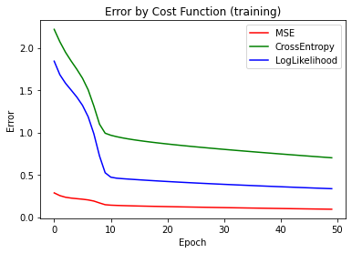

```python
MSE = []
CE = []
LL = []

for res in results4[0]:
    MSE.append(res[2])
    CE.append(res[3])
    LL.append(res[4])

plt.plot(MSE, c='red', label='MSE')
plt.plot(CE, c='green', label='CrossEntropy')
plt.plot(LL, c='blue', label='LogLikelihood')
plt.legend()
plt.ylabel('Error')
plt.xlabel('Epoch')
plt.title('Error by Cost Function (training)')

plt.show()
```

**D-B. Three plots, one for each cost function, that shows the error for training vs. test:**

```python
test_MSE = []
test_CE = []
test_LL = []

for res in results4[1]:
    test_MSE.append(res[2])
    test_CE.append(res[3])
    test_LL.append(res[4])
```

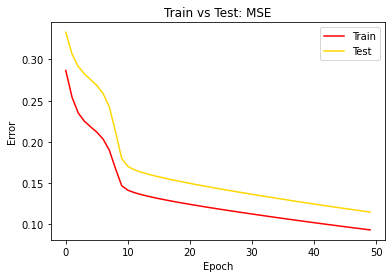

```python
plt.plot(MSE, c='red', label='Train')
plt.plot(test_MSE, c='gold', label='Test')
plt.legend()
plt.ylabel('Error')
plt.xlabel('Epoch')
plt.title('Train vs Test: MSE')

plt.show()
```

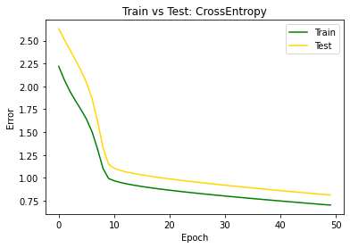

```python
plt.plot(CE, c='green', label='Train')
plt.plot(test_CE, c='gold', label='Test')
plt.legend()
plt.ylabel('Error')
plt.xlabel('Epoch')
plt.title('Train vs Test: CrossEntropy')

plt.show()
```

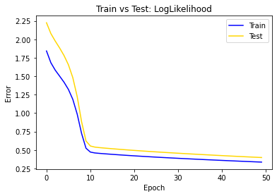

```python
plt.plot(LL, c='blue', label='Train')
plt.plot(test_LL, c='gold', label='Test')
plt.legend()
plt.ylabel('Error')
plt.xlabel('Epoch')
plt.title('Train vs Test: LogLikelihood')

plt.show()
```